# Accessibility links

### How to Read a Tape Measure - The Home Depot

homedepot.com

https://www.homedepot.com › how-to-read-a-tape-meas...

homedepot.com

https://www.homedepot.com › how-to-read-a-tape-meas...

Search for: [Are tape measures in cm or mm?](https://www.google.com/search?sca_esv=565345942&sxsrf=AM9HkKmSIYkhd-w3bi6Gmg1Dx5FLpoUCxA:1694703471872&q=Are+tape+measures+in+cm+or+mm%3F&sa=X&sqi=2&ved=2ahUKEwjD4sKzrqqBAxVxT6QEHTmjCNAQzmd6BAghEAY)

Which one is cm on a tape measure?

If you have a metric tape measure, the numbers should be read like this: **The large, numbered markings are centimeters**. There is a smaller marking exactly halfway between the centimeters for ease of reading. The smallest markings are millimeters, or one tenth of a centimeter.

### Accurately Reading a Tape Measure

ustape.com

https://www.ustape.com › accurately-reading-a-tape-mea...

ustape.com

https://www.ustape.com › accurately-reading-a-tape-mea...

Search for: [Which one is cm on a tape measure?](https://www.google.com/search?sca_esv=565345942&sxsrf=AM9HkKmSIYkhd-w3bi6Gmg1Dx5FLpoUCxA:1694703471872&q=Which+one+is+cm+on+a+tape+measure%3F&sa=X&sqi=2&ved=2ahUKEwjD4sKzrqqBAxVxT6QEHTmjCNAQzmd6BAggEAY)

[Feedback](https://www.google.com/search?q=measuring+tape&oq=measuring+tape&aqs=chrome..69i57j0i512l9.1796j0j4&sourceid=chrome&ie=UTF-8&bshm=rime/1#)

### Tape measure

Wikipedia

https://en.wikipedia.org › wiki › Tape_measure

Wikipedia

https://en.wikipedia.org › wiki › Tape_measure

A tape measure or *measuring tape* is a flexible ruler used to measure length or distance. Plastic tape measure (cm) Manually reeled tape measure Self ...

### How to Read a Tape Measure

Johnson Level

https://www.johnsonlevel.com › News › TapeMeasure

Johnson Level

https://www.johnsonlevel.com › News › TapeMeasure

*Tape* measures are made from a variety of materials, including fiber glass, plastic and cloth. They are among the most common *measuring* tools used today.

### Tape Measures | Measuring Tools

Screwfix

https://www.screwfix.com › Tools › Measuring Tools

Screwfix

https://www.screwfix.com › Tools › Measuring Tools

Huge range of *Tape* Measures at Screwfix.com. Metric and imperial scales. Various types available. Buy online and collect in store in as little as 1 minute.

### What is Measuring Tape? Definition, Units, Example, Facts

SplashLearn

https://www.splashlearn.com › measurements › measur...

SplashLearn

https://www.splashlearn.com › measurements › measur...

A *measuring tape* is a flexible tool used for measuring length. It is made up of materials like fiberglass, cloth, plastic, metal ribbon or strip. So, it is a ...

### measuring tape - Traduction française

Linguee

https://www.linguee.fr › anglais-francais › measuring+...

Linguee

https://www.linguee.fr › anglais-francais › measuring+...

Use a *measuring tape* to find out length and height measurements, [...] solve problems and complete simple additions. pierrebelvedere.com. pierrebelvedere.com.

### How to Read a Tape Measure

The Tape Store

https://www.thetapestore.co.uk › knowledgebase › ho...

The Tape Store

https://www.thetapestore.co.uk › knowledgebase › ho...

Feb 14, 2014 — Learn how to read both metric and imperial *tape* measures properly! Helpful advice from The *Tape* Store - The UK's *tape measure* specialists.

### Tape Measure® on the App Store

Apple

https://apps.apple.com › app › tape-measure

Apple

https://apps.apple.com › app › tape-measure

Read reviews, compare customer ratings, see screenshots, and learn more about *Tape Measure*®. Download *Tape Measure*® and enjoy it on your iPhone, iPad, ...

Rating: 4.6 · 29,560 reviews · Free · iOS · Utilities/Tools

Reviews aren’t verified by Google Search

### Tape Measures at Lowes.com

Lowe's

https://www.lowes.com › ... › Measuring Tools

Lowe's

https://www.lowes.com › ... › Measuring Tools

Find *tape* measures at Lowe's today. Free Shipping On Orders $45+. Shop *tape* measures and a variety of tools products online at Lowes.com.

### Tape Measures - Measuring Tools

Home Depot

https://www.homedepot.com › ... › Measuring Tools

Home Depot

https://www.homedepot.com › ... › Measuring Tools

A digital *tape measure* gives an electronic reading, and it can even convert fractions to decimals and inches to centimeters. • Laser ...

Others want to know

[Feedback](https://www.google.com/search?q=measuring+tape&oq=measuring+tape&aqs=chrome..69i57j0i512l9.1796j0j4&sourceid=chrome&ie=UTF-8&bshm=rime/1#)

Related searches

Measuring tape how to read

[figure not shown]

See more

Measuring tape drawing

[figure not shown]

See more

[Feedback](https://www.google.com/search?q=measuring+tape&oq=measuring+tape&aqs=chrome..69i57j0i512l9.1796j0j4&sourceid=chrome&ie=UTF-8&bshm=rime/1#)

measuring tape **online**

measuring tape **for body**

measuring tape **on phone**

measuring tape **app**

measuring tape **used for**

measuring tape **nearby**

# Page Navigation

Sponsored

Sponsored

My Ad Centre

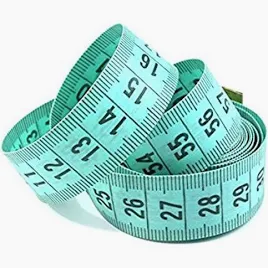

[Bobury 150cm / 60 "Body Measuring Ruler Couture Tailor Mesure à ruban Soft Flat (couleur aléatoire)Bobury 150cm / 60 "Body Measuring Ruler Couture Tailor Mesure à ruban Soft Flat (couleur aléatoire)](https://www.amazon.fr/Bobury-Measuring-Couture-couleur-al%C3%A9atoire/dp/B06XWF8VWX?source=ps-sl-shoppingads-lpcontext&ref_=fplfs&psc=1&smid=A3JDX274A7HBER)

€2.99

Amazon.frAmazon.fr

Free shipping

By Google

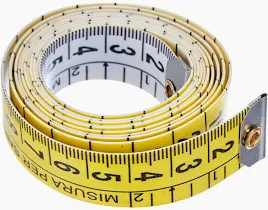

[Metrica 22091 Mètre à ruban pour Couturier 1,5 mMetrica 22091 Mètre à ruban pour Couturier 1,5 m](https://www.amazon.fr/Metrica-22091-M%C3%A8tre-ruban-Couturier/dp/B00ATJPZ3O?source=ps-sl-shoppingads-lpcontext&ref_=fplfs&psc=1&smid=A2WX0PQ1EZ091M)

€3.79

Amazon.frAmazon.fr

Free shipping

By Google

[figure not shown]

Metrica 22091 Mètre à ruban pour Couturier 1,5 m

€3.79

Amazon.fr

By Google

Compare related products from 50+ shops.

[figure not shown]

[STANLEY Mesure 3 m x 13 mm Bi-Matière Tylon - Métre à Ruban Léger, Compact et Ergonomique avec Crochet de Ceinture 0-30-687STANLEY Mesure 3 m x 13 mm Bi-Matière Tylon - Métre à Ruban Léger, Compact et Ergonomique avec Crochet de Ceinture 0-30-687](https://www.amazon.fr/Stanley-0-30-687-Mesure-bi-mati%C3%A8re-Tylon/dp/B003Y6ISWO?source=ps-sl-shoppingads-lpcontext&ref_=fplfs&psc=1&smid=A1X6FK5RDHNB96)

€6.90

Amazon.frAmazon.fr

+€4.99 shipping

By Google

[figure not shown]

STANLEY Mesure 3 m x 13 mm Bi-Matière Tylon - Métre à Ruban Léger, Compact et Ergonomique avec Crochet de Ceinture 0-30-687

€6.90

+€4.99 shipping

Amazon.fr

By Google

Compare related products from 50+ shops.

[figure not shown]

[Stanley 0-30-697 mesure Tylon 5m x 19mm - Boitier Ergonomique Bi matière - Ruban en Acier Laqué - Crochet 2 Rivets - Position du Zéro Réel - AgrafeStanley 0-30-697 mesure Tylon 5m x 19mm - Boitier Ergonomique Bi matière - Ruban en Acier Laqué - Crochet 2 Rivets - Position du Zéro Réel - Agrafe](https://www.amazon.fr/Stanley-0-30-697-Mesure-mati%C3%A8re-tylon/dp/B000XJ02LU?source=ps-sl-shoppingads-lpcontext&ref_=fplfs&psc=1&smid=A1X6FK5RDHNB96)

€10.90

Amazon.frAmazon.fr

+€4.99 shipping

By Google

[figure not shown]

Stanley 0-30-697 mesure Tylon 5m x 19mm - Boitier Ergonomique Bi matière - Ruban en Acier Laqué - Crochet 2 Rivets - Position du Zéro Réel - Agrafe

€10.90

+€4.99 shipping

Amazon.fr

By Google

Compare related products from 50+ shops.

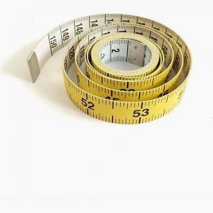

[BABARONI TAPE MEASUREBABARONI TAPE MEASURE](https://babaroni.fr/products/babaroni-tape-measure?variant=45329665589527)

€1.00

BabaroniBabaroni

Free shipping

By Google

[figure not shown]

BABARONI TAPE MEASURE

€1.00

Babaroni

By Google

Compare related products from 50+ shops.

[figure not shown]

[Decathlon - Metre Ruban De Pêche "measure" - Mètre - Peches Des Carnassiers - - Taille Unique - CaperlanDecathlon - Metre Ruban De Pêche "measure" - Mètre - Peches Des Carnassiers - - Taille Unique - Caperlan](https://www.decathlon.fr/p/metre-ruban-de-peche-measure/_/R-p-329238?mc=8607181)

€3.00

Decathlon.frDecathlon.fr

+€4.00 shipping

By Yteo

[figure not shown]

Decathlon - Metre Ruban De Pêche "measure" - Mètre - Peches Des Carnassiers - - Taille Unique - Caperlan

€3.00

+€4.00 shipping

Decathlon.fr

By Yteo

Compare related products from 10+ shops.

[figure not shown]

€13.90

Amazon.frAmazon.fr

+€4.99 shipping

By Google

[figure not shown]

STANLEY Mètre Tylon Bi Matière 8m x 25mm - Ruban Anti-Corrosion - Boitier Bi Matière - Blocage du Ruban - Crochet 3 Rivets - Position du Zéro Réel -

€13.90

+€4.99 shipping

Amazon.fr

By Google

Compare related products from 50+ shops.

[figure not shown]

€3.82

TemuTemu

+€3.90 shipping

By Google

[figure not shown]

Ensemble De Ruban À Mesurer Rétractable De 16 Pieds - Lecture Facile, Enroulement Automatique Et Verrouillage - Parfait Pour Les Ingénieurs Et Les

€3.82

+€3.90 shipping

Temu

By Google

Compare related products from 50+ shops.

[figure not shown]

In store

[Mètre ruban ruban abs STANLEY 0-34-297 30 mMètre ruban ruban abs STANLEY 0-34-297 30 m](https://www.leroymerlin.fr/produits/outillage/outillage-a-main/metre-niveau-et-outils-de-mesure-et-tracage/odometre/metre-ruban-ruban-abs-stanley-0-34-297-30-m-31956022.html?storeid=53)

€13.90

Leroy MerlinLeroy Merlin

[(64)](https://www.google.com/search?q=measuring+tape&oq=measuring+tape&aqs=chrome..69i57j0i512l9.1796j0j4&sourceid=chrome&ie=UTF-8&bshm=rime/1#)

By Arcane

[figure not shown]

In store

Mètre ruban ruban abs STANLEY 0-34-297 30 m

€13.90

Leroy Merlin

[(64)](https://www.google.com/search?q=measuring+tape&oq=measuring+tape&aqs=chrome..69i57j0i512l9.1796j0j4&sourceid=chrome&ie=UTF-8&bshm=rime/1#)

By Arcane

Compare related products from 5 shops.

### Images

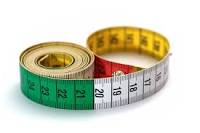

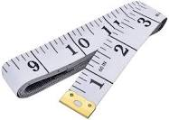

[figure not shown]

[figure not shown]

More images

[figure not shown]

Facebook

[figure not shown]

Twitter

[figure not shown]

Email

Click to copy link

Share link

## Tape Measure

Mathematical tool

### Description

A tape measure or measuring tape is a flexible ruler used to measure length or distance. It consists of a ribbon of cloth, plastic, fibre glass, or metal strip with linear measurement markings. It is a common measuring tool. [Wikipedia](https://en.wikipedia.org/wiki/Tape_measure)

Operation supported: Distance measurement

Purpose: To serve as a tool for measuring distance

Made of material option: Plastic, Steel, Metal, Fiberglass, Linen, Invar

Component: Strip with linear-measurement marking, Ribbon of cloth

Application: Surveyor

Or give [general feedback](https://www.google.com/search?q=measuring+tape&oq=measuring+tape&aqs=chrome..69i57j0i512l9.1796j0j4&sourceid=chrome&ie=UTF-8&bshm=rime/1#)

Feedback

Google apps

Google Account

Bede Ffinian Rowe Davies

[interactive chart not shown]